# Personalized Grit Lab Report

Updated March 4, 2021

Hi Kevin,

Welcome to your personalized Grit Lab report!

We will go week by week, reviewing everything you have told us through Poll Everywhere so far.

We hope this will help you reflect on what you learned and experienced during the first half of the lectures of Grit Lab.

Important note!

Sometimes, you may not have been able to respond to all polls.

If the data for one of the polls is missing, the automatic report will display "NA" or "".

Okay, let's get started!

The first half of Grit Lab delves deep into the passion component of Grit.

We like to call it "Choose Easy", because we think gritty people pursue what they enjoy.

Putting it graphically, gritty people pursue the intersection of these four circles.

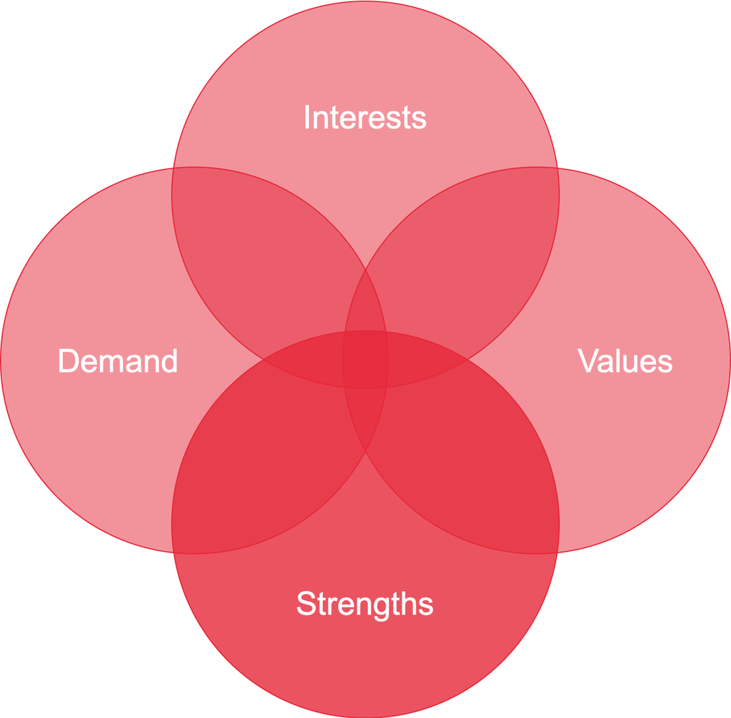

The first time we met, you told us where you were on the grit rubric.

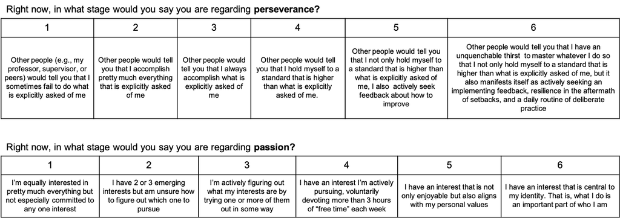

Regarding passion you picked Stage 5: I have an interest that is not only enjoyable but also aligns with my personal values.

Regarding perseverance you picked Stage 5: Other people would tell you that I not only hold myself to a standard that is higher than what is explicitly asked of me, I also actively seek feedback about how to improve.

This chart shows how you rated yourself on a 1 - 6 scale.

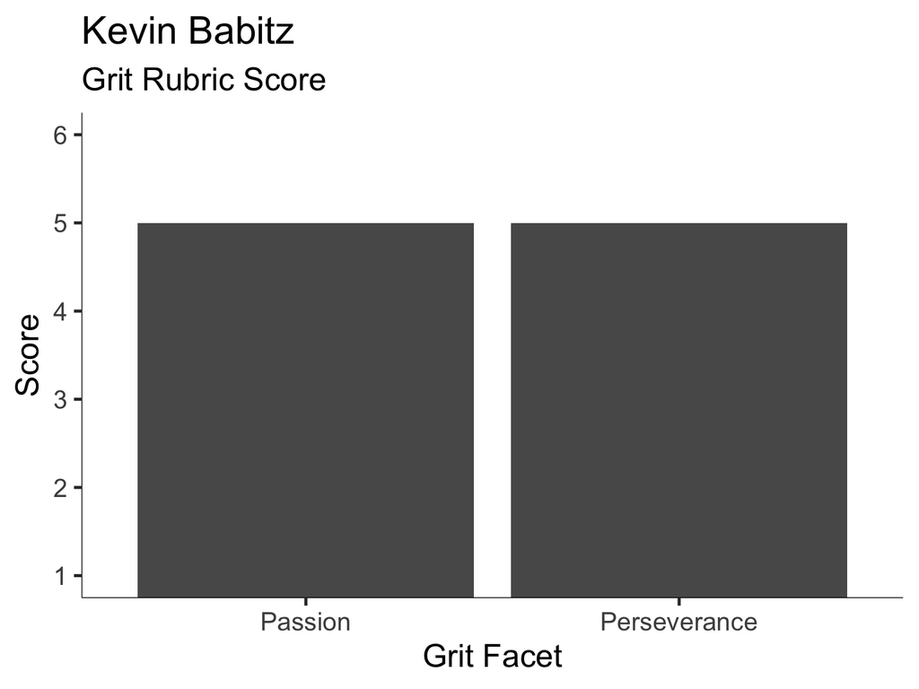

As you know, grit grows, so don’t worry if you are not yet where you’d like to be in your grit development.

Hopefully, this class will help you become grittier each day.

On week 2 we looked at your interests.

Interest is an emotion, and it is the opposite of boredom.

Your interests are the activities or subjects that spontaneously grab your attention.

Trying things out and seeing how you feel is the best way to refine your interests

Here is the quote you wrote to summarize this class.

"Try to leave the world a better place because you were in it"

On week 3, we studied values, your beliefs about what is important

You said your top three values were achievement, stimulation, and benevolence.

Here is the quote you wrote to summarize this class.

"It's is important to be honest, be a student of life (and keep learning always), and to forgive people"

You wrote a "This I Believe" essay, and here's where you located it on Schwartz’s value taxonomy.

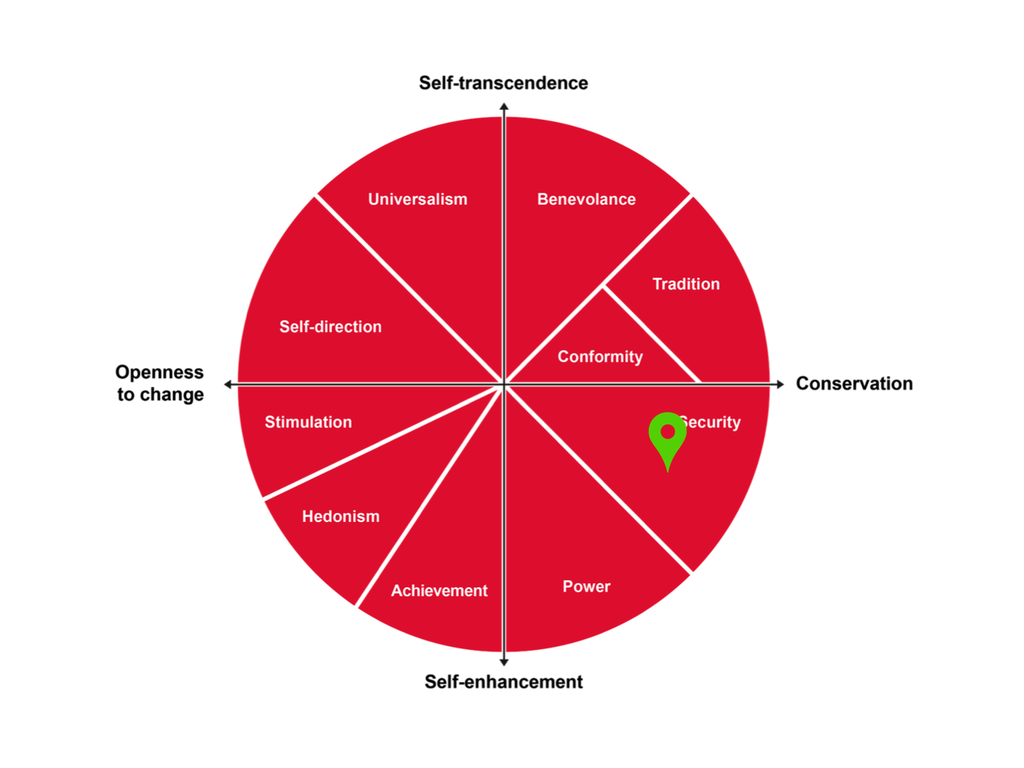

When we talked about strengths on week 4, you said your personality strength was agreeableness.

You said your top three talents were analytic, verbal, and kinesthetic.

Here is the quote you wrote to summarize this class.

"Talent is a rate variable for how fast you can learn a skill while effort determines how much you can learn"

We then talked about goal hierarchies.

Here's how you said you felt about your top-level goal.

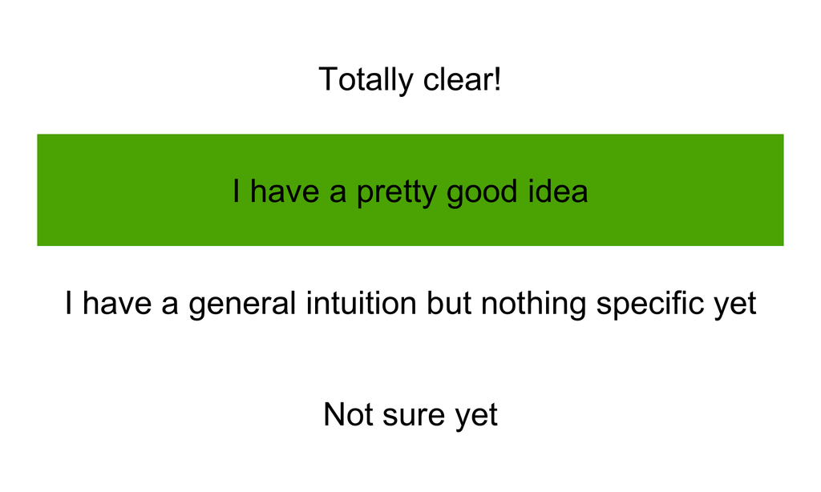

We discussed self concordance, or how much a goal aligns to your deeply held values and beliefs.

A goal you said you will be pursuing for the next six months is to graduate and start job.

Here is how self-concordant that goal was, compared to the rest of the class.

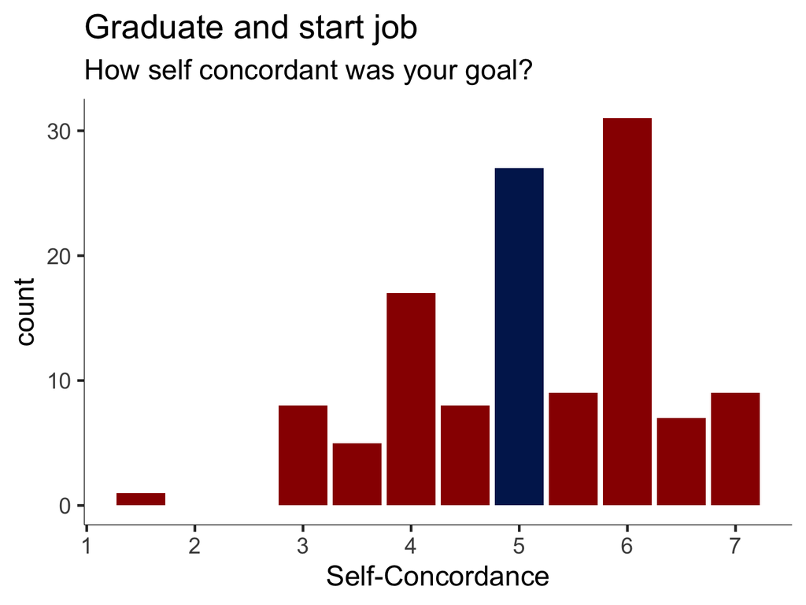

You are in the blue bar!

Don't worry if your self-concordance for that particular goal is low.

It might mean that you need to reframe that goal in a way that makes it more relevant to your deep self, or change it!

Remember that self-concordance is goal specific, so other goals might be more self-concordant.

Here is the quote you wrote to summarize this class.

"Having a very fluid and synergistic goal hierarchy is very valuable and seem in a lot of gritty people"

Here's how your mood has been through the semester.

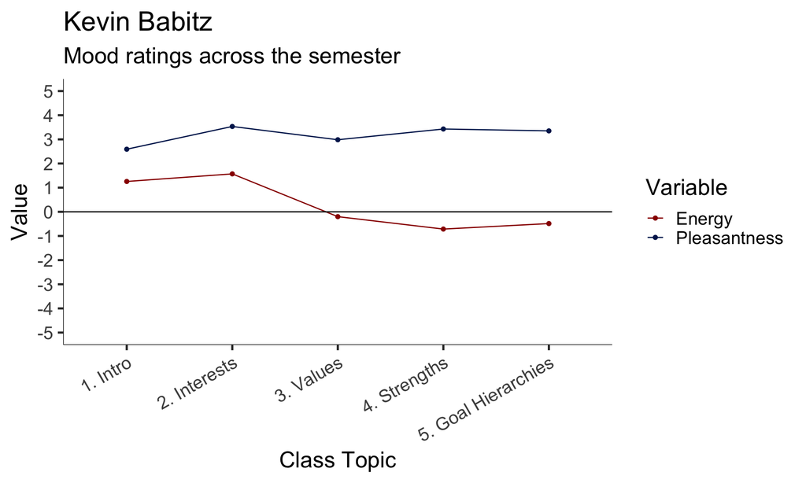

Here are all the questions you've had throughout the semester.

[output not shown]

Make sure to go to your TA's office hours if you want to talk about these. It'll be fun for both of you.

We hope this has been useful to you!

With grit and gratitude,

Angela and the Grit Lab team.